# Hands-on Exercise: Interaction analysis in a COVID dataset

## 4 Gender:Disease interaction

Such a difference would be captured by the interaction term, i.e. the `gender:disease` coefficient of the model, which in the DESeq2 results is named ‘gendermale.diseaseCOVID’ :

```r
res.inter <- results(dds, name="gendermale.diseaseCOVID")
res.inter <- res.inter[order(res.inter$pvalue),]
head(res.inter)
```

```
log2 fold change (MLE): gendermale.diseaseCOVID
Wald test p-value: gendermale.diseaseCOVID
DataFrame with 6 rows and 6 columns
          baseMean log2FoldChange     lfcSE      stat      pvalue      padj
         <numeric>      <numeric> <numeric> <numeric>   <numeric> <numeric>
TBC1D3F   41.28131       21.07153  4.512569   4.66952 3.01903e-06 0.0540015
LRRC23    61.87935       -1.37126  0.361678  -3.79137 1.49820e-04 0.9997296
E2F7      18.91916        4.12725  1.109848   3.71875 2.00211e-04 0.9997296
CLVS1      3.86782       -3.72642  1.046969  -3.55924 3.71926e-04 0.9997296
XCR1      24.37076       -3.01006  0.861339  -3.49463 4.74715e-04 0.9997296
EIF1AY  1157.70235       -6.38803  1.934751  -3.30173 9.60891e-04 0.9997296
```

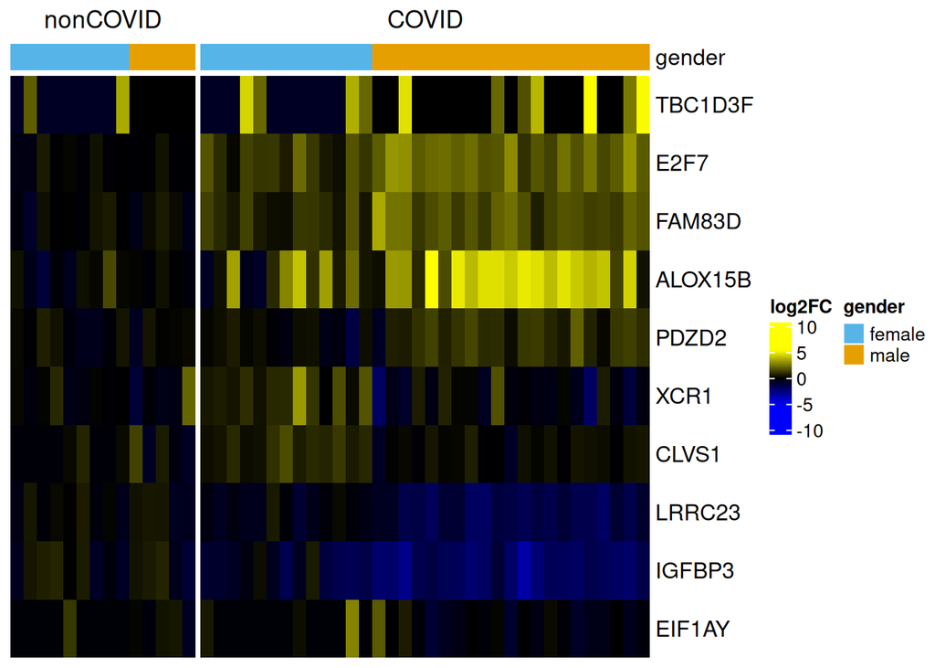

```r
sechm(se, head(row.names(res.inter), 10), gaps_at="disease", top_annotation="gender")
```

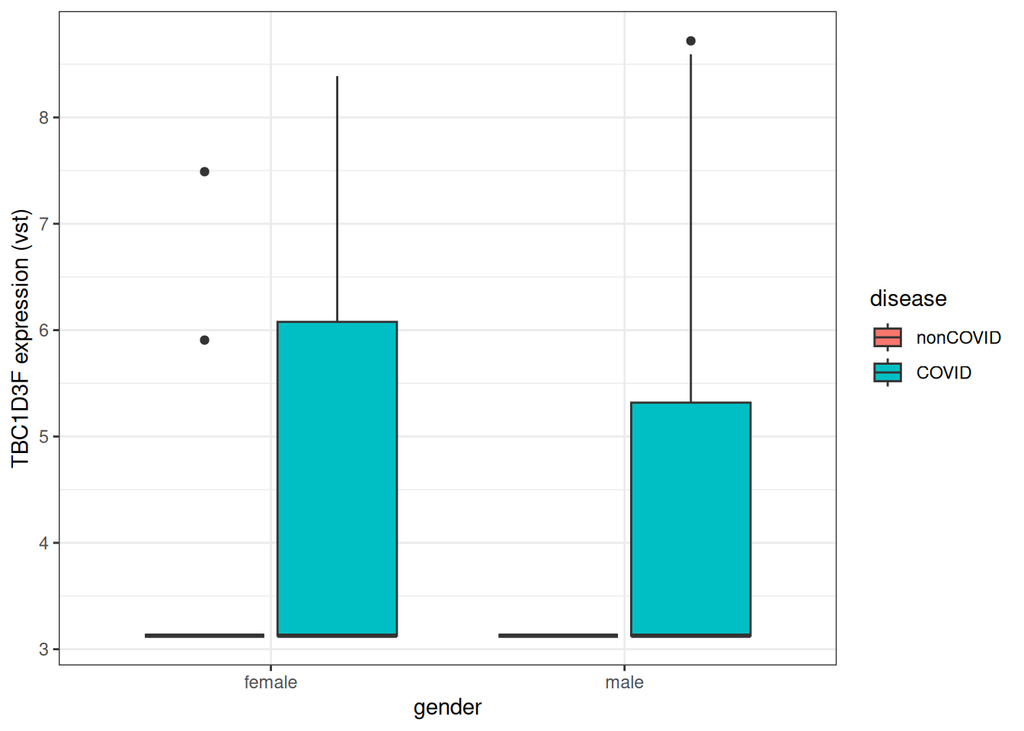

```r
ggplot(meltSE(se, "TBC1D3F"), aes(gender, vst, fill=disease)) + geom_boxplot() + theme_bw() + ylab("TBC1D3F expression (vst)")
```

**NoteWhy was TBC1D3F called in the first place?**

Model fitting is challenging in the presence of outliers or when a group has all zero counts, as is the case for this gene. Here `edgeR`’s quasi-likelihood approach would most likely yield a better calibrated estimate of significance for this genes.

Does the lack of significance mean that males and females respond the same? Clearly we can’t conclude that: *absence of evidence is not evidence of absence*. It could simply be that we do not have the power to detect such differences, although the fact that we do detect massive differences between disease states does indicate that disease-sex interactions, if there are any, are relatively mild.

### 4.1 Staged FDR analysis

Statistically speaking, testing for an interaction is more difficult than testing for main effects. Fortunately, there is a strategy that can help us increase power.

In a normal ANOVA, one starts by asking the more generic questions, and conditional on the significance of the higher-order variables, one then asks more fine-grained questions. In contrast, when running our DEA we are testing every hypothesis for every gene, even when it doesn’t make sense to test something very specific.

The `stageR` package has been designed to do an analog of this hierarchical approach, working at the FDR level. Simplified, what it does is test for interaction only in a subset of the genes which, based on a more general test (called ‘screening’), is more likely to show an interaction.

For this, we first need the screening test, which will be the test of whether any of the coefficient is non-zero (in other words, whether the full model, `~gender*disease`, explains the data significantly better than a null model `~1`).

```r
dds.lrt <- DESeq(dds, test = "LRT", reduced = ~ 1)
```

```
found already estimated dispersions, replacing these
```

```
-- replacing outliers and refitting for 186 genes
-- DESeq argument 'minReplicatesForReplace' = 7
-- original counts are preserved in counts(dds)
```

```r
res.any <- results(dds.lrt)
res.any <- res.any[!is.na(res.any$padj),]

screening.padj <- res.any$padj
confirm.pvalue <- res.inter[row.names(res.any), "pvalue"]
```

Now that we have the results of both the screening test and our interaction (so-called ‘confirmation’) test, we can run stageR:

```r
staged <- stageR(pScreen=screening.padj, pConfirmation=cbind(interaction=confirm.pvalue), pScreenAdjusted = TRUE)
staged <- stageWiseAdjustment(staged, method="none", alpha=0.05)
stage.padj <- getAdjustedPValues(staged, onlySignificantGenes=FALSE, order=FALSE)
```

```
The returned adjusted p-values are based on a stage-wise testing approach and are only valid for the provided target OFDR level of 5%. If a different target OFDR level is of interest,the entire adjustment should be re-run.
```

```r
row.names(stage.padj) <- row.names(res.any)

# we put the stage-adjusted pvalues in the original DEA object:
res.inter$stage.padj <- as.data.frame(stage.padj)[row.names(res.inter), "interaction"]
res.inter <- res.inter[order(res.inter$stage.padj),]
head(res.inter)
```

```
log2 fold change (MLE): gendermale.diseaseCOVID
Wald test p-value: gendermale.diseaseCOVID
DataFrame with 6 rows and 7 columns
         baseMean log2FoldChange     lfcSE      stat      pvalue      padj
        <numeric>      <numeric> <numeric> <numeric>   <numeric> <numeric>
LRRC23   61.87935       -1.37126  0.361678  -3.79137 0.000149820   0.99973
E2F7     18.91916        4.12725  1.109848   3.71875 0.000200211   0.99973
CLVS1     3.86782       -3.72642  1.046969  -3.55924 0.000371926   0.99973
XCR1     24.37076       -3.01006  0.861339  -3.49463 0.000474715   0.99973
EIF1AY 1157.70235       -6.38803  1.934751  -3.30173 0.000960891   0.99973
FAM83D   22.28160        2.39851  0.734280   3.26647 0.001088963   0.99973
        stage.padj
         <numeric>
LRRC23 0.000298586
E2F7   0.000399014
CLVS1  0.000741238
XCR1   0.000946093
EIF1AY 0.001915026
FAM83D 0.002170270
```

```r
sum(res.inter$stage.padj<0.05, na.rm=TRUE)
```

```
[1] 162
```

In this way, we’ve identified 162 genes with a significant gender:disease interaction:

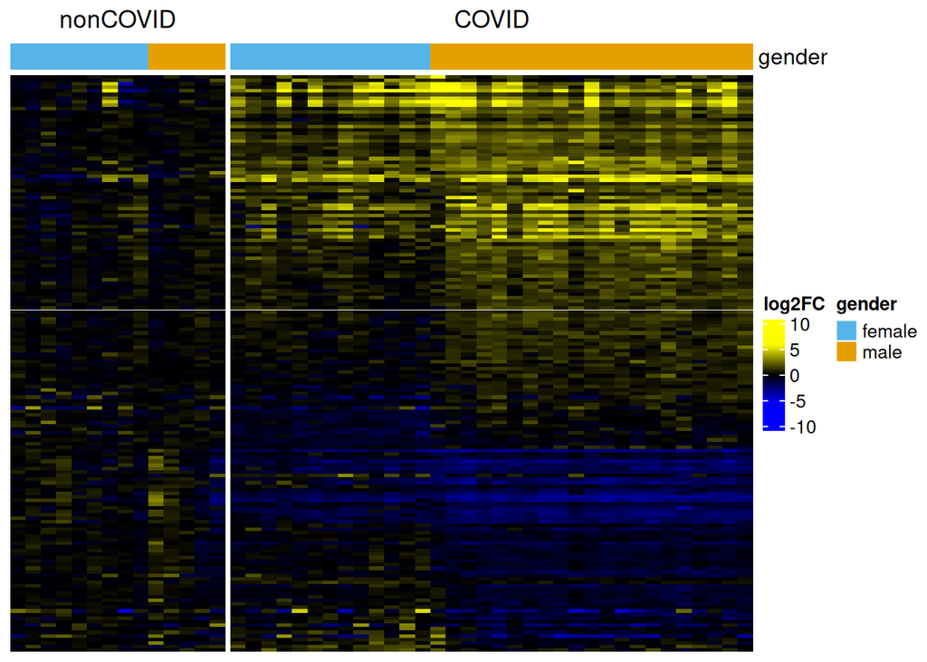

```r
interDEGs <- row.names(res.inter)[which(res.inter$stage.padj<0.05)]
sechm(se, interDEGs, gaps_at="disease", top_annotation="gender")
```

One could then go on to characterize these genes, for instance through geneset enrichment analysis.

## 5 An alternative approach using contrasts

As an alternative testing framework (also available in DESeq2, as well as alternatives such as edgeR and limma/voom), one can use contrasts. Contrasts allow us to formulate differences between groups, corrected for the other factors included in the model. To do this, it is easier to first flatten the groups so that they are represented in a single variable:

```r
se$group <- paste(se$gender, se$disease, sep=".")
table(se$group)
```

```
   female.COVID female.nonCOVID      male.COVID   male.nonCOVID
             13               9              21               5
```

Then, we formulate our model without an intercept:

```r
dds <- DESeqDataSet(se, ~0+group)
dds <- DESeq(dds)
```

```
-- replacing outliers and refitting for 186 genes
-- DESeq argument 'minReplicatesForReplace' = 7
-- original counts are preserved in counts(dds)
```

Finally, we express the comparisons of interest (contrasts):

```r
my.contrasts <- limma::makeContrasts(
  femaleDisease=female.COVID-female.nonCOVID, # effects of COVID in females --> the equivalent of the earlier 'disease_COVID_vs_nonCOVID' test
  maleDisease=male.COVID-male.nonCOVID, # effects of COVID in males
  meanDisease=(female.COVID+male.COVID)/2-(female.nonCOVID+male.nonCOVID)/2, # average effect of COVID across genders
  interaction=(male.COVID-male.nonCOVID)-(female.COVID-female.nonCOVID), # interaction --> the equivalent of the earlier 'gendermale.diseaseCOVID' test
  levels=gsub("^group","", resultsNames(dds))
)

# Then we can test a specific contrast, e.g. again the interaction:
res.inter2 <- results(dds, contrast = my.contrasts[,"interaction"])
res.inter2 <- res.inter2[order(res.inter2$pvalue),]

# and we can see that the results are virtually identical with our previous analysis:
head(res.inter2)
```

```
log2 fold change (MLE): -1,+1,+1,-1
Wald test p-value: -1,+1,+1,-1
DataFrame with 6 rows and 6 columns
         baseMean log2FoldChange     lfcSE      stat      pvalue      padj
        <numeric>      <numeric> <numeric> <numeric>   <numeric> <numeric>
TBC1D3F  41.28131       22.40125  4.512699   4.96405 6.90392e-07  0.012349
LRRC23   61.87935       -1.37126  0.361678  -3.79137 1.49820e-04  0.999738
E2F7     18.91916        4.12726  1.109850   3.71875 2.00210e-04  0.999738
CLVS1     3.86782       -3.72642  1.046971  -3.55924 3.71928e-04  0.999738
XCR1     24.37076       -3.01007  0.861340  -3.49463 4.74718e-04  0.999738
TBC1D3K  20.41062      -22.46743  6.652154  -3.37747 7.31566e-04  0.999738
```

## 6 Beyond single-gene hypotheses

### 6.1 Global differences in magnitude

The results of the interaction analysis above, and especially the heatmap visualization, suggest no qualitative difference between the disease signature in the two genders, but rather a difference in degree. Specifically, *in those genes* the response appears stronger in males. Since we are looking only at significant interactions, however, it is not clear how these patterns extend to other response genes. This prompt the question of whether there is a *global* trend of a difference in the *magnitude* of the response between genders.

Testing such a hypothesis is considerably easier (from a power point of view) than testing gene-specific interactions. All we need to do is test whether the slope comparing the disease logFC in each group differs from the diagonal (i.e. slope=1).

As we saw in the theoretical part, however, the crucial thing is the selection of the genes. To avoid the regression to the mean bias, the selection needs to be unbiased between males and females.

We therefore take the results of the contrast that looks for disease differences averaged across genders:

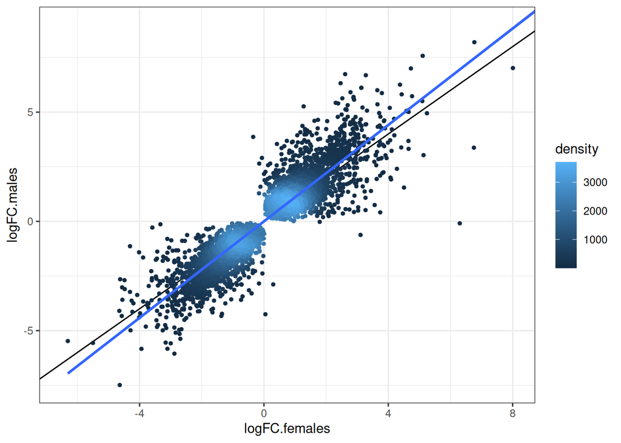

```r
names(conts) <- conts <- colnames(my.contrasts)
resl <- lapply(conts, \(x) results(dds, contrast = my.contrasts[,x]))
d <- data.frame(row.names=row.names(resl[[1]]),
                logFC.males=resl$maleDisease$log2FoldChange,
                logFC.females=resl$femaleDisease$log2FoldChange,
                padj.mean=resl$meanDisease$padj)
d <- d[which(d$padj.mean<0.05),]
ggplot(d, aes(logFC.females, logFC.males)) + geom_abline(slope=1) +
  ggpointdensity::geom_pointdensity(size=1) + coord_cartesian(xlim=c(-6.5,8), ylim=c(-7.5,9)) +
  theme_bw() + geom_smooth(formula=y~0+x, method="lm")
```

**NoteFitting a model on logFC scatterplots**

Note that, when the number of points (i.e. DEGs) is small, fits such as the one plotted here on the scatterplot can easily be mislead by outliers. When this is the case, a more accurate fit can be achived through robust linear models (see `MASS::rlm`). However, statistical testing with such models is more challenging. For the purpose of illustration, and as we do not have such a problem here, we stick to using a standard linear model.

For the purpose of making a statistical test, we can simplify this as asking whether the average difference differs from zero:

```r
summary(lm(logFC.males - logFC.females ~ 0 + logFC.females, data = d))
```

```
Call:
lm(formula = logFC.males - logFC.females ~ 0 + logFC.females,
    data = d)

Residuals:
     Min       1Q   Median       3Q      Max
-25.0268  -0.2984  -0.0431   0.2154  22.2967

Coefficients:
              Estimate Std. Error t value Pr(>|t|)
logFC.females  0.10347    0.00555   18.64   <2e-16 ***
---
Signif. codes:  0 '***' 0.001 '**' 0.01 '*' 0.05 '.' 0.1 ' ' 1

Residual standard error: 0.6785 on 9271 degrees of freedom
Multiple R-squared:  0.03614,   Adjusted R-squared:  0.03603
F-statistic: 347.6 on 1 and 9271 DF,  p-value: < 2.2e-16
```

Males do, globally, respond (roughly 10%) more strongly.